# Coffee Shop Survey Report

Kabamba Mutale

2025-04-22

# **Install & Load Libraries**

Install packages by running **install.packages(c(“dplyr”, “ggplot2”, “readr”))** in the console. This tells R to install the listed packages in one go first if they are not, thereafter, you just load them.

```r
# Load libraries and set global options
library(readxl)
library(tidyverse)
```

```r
library(ggplot2)
library(dplyr)
library(rmarkdown)
library(tinytex)
```

# **Import Data**

Use `read_excel` to load the dataset by providing the path for your dataset.

```r
#Loading Data
data <- read_excel("J:/r/coffee_shop_survey.xlsx")
```

# **Inspecting the Data**

**View the structure**

```r
# View the structure
str(data)
```

```
## tibble [100 × 9] (S3: tbl_df/tbl/data.frame)
##  $ Customer_ID       : chr [1:100] "CUST001" "CUST002" "CUST003" "CUST004" ...
##  $ Age               : num [1:100] 56 46 32 60 25 38 56 36 40 28 ...
##  $ Gender            : chr [1:100] "Male" "Male" "Male" "Female" ...
##  $ Visit_Frequency   : num [1:100] 1 2 6 2 3 7 6 3 0 0 ...
##  $ Favorite_Product  : chr [1:100] "Sandwich" "Sandwich" "Pastry" "Pastry" ...
##  $ Satisfaction_Score: num [1:100] 2 1 5 4 2 1 4 5 4 1 ...
##  $ Time_Spent (min)  : num [1:100] 53 32 36 31 24 28 16 54 39 37 ...
##  $ Loyalty_Member    : chr [1:100] "Yes" "No" "Yes" "Yes" ...
##  $ Would_Recommend   : chr [1:100] "No" "Yes" "Yes" "Yes" ...
```

**View the first few rows**

```r
# View the first few rows
head(data)
```

```
## # A tibble: 6 × 9
##   Customer_ID   Age Gender Visit_Frequency Favorite_Product Satisfaction_Score
##   <chr>       <dbl> <chr>            <dbl> <chr>                         <dbl>
## 1 CUST001        56 Male                 1 Sandwich                          2
## 2 CUST002        46 Male                 2 Sandwich                          1
## 3 CUST003        32 Male                 6 Pastry                            5
## 4 CUST004        60 Female               2 Pastry                            4
## 5 CUST005        25 Female               3 Tea                               2
## 6 CUST006        38 Female               7 Pastry                            1
## # ℹ 3 more variables: `Time_Spent (min)` <dbl>, Loyalty_Member <chr>,
## #   Would_Recommend <chr>
```

# **Cleaning Data**

**Check for missing values**

```r
# Check for missing values
colSums(is.na(data))
```

```
##        Customer_ID                Age             Gender    Visit_Frequency
##                  0                  0                  0                  0
##   Favorite_Product Satisfaction_Score   Time_Spent (min)     Loyalty_Member
##                  0                  0                  0                  0
##    Would_Recommend
##                  0
```

**Remove rows with any NA values (optional)**

```r
# Remove rows with any NA values (optional)
data2 <- na.omit(data)
```

**Changing column name (optional)**

```r
# changing column name
names(data2)[names(data2) == "Time_Spent (min)"] <- "Time_Spent_min"
```

**Confirming column name change (optional)**

```r
# Check column names
colnames(data2)
```

```
## [1] "Customer_ID"        "Age"                "Gender"
## [4] "Visit_Frequency"    "Favorite_Product"   "Satisfaction_Score"
## [7] "Time_Spent_min"     "Loyalty_Member"     "Would_Recommend"
```

# **Descriptive Analysis**

### **1. What is the average age of customers visiting the coffee shop?**

```r
# Average Age of Customers

average_age <- mean(data2$Age,na.rm = TRUE)
print(paste("Average Age:", round(average_age, 1)))
```

```
## [1] "Average Age: 40.9"
```

**Visual KPI for Average Age**

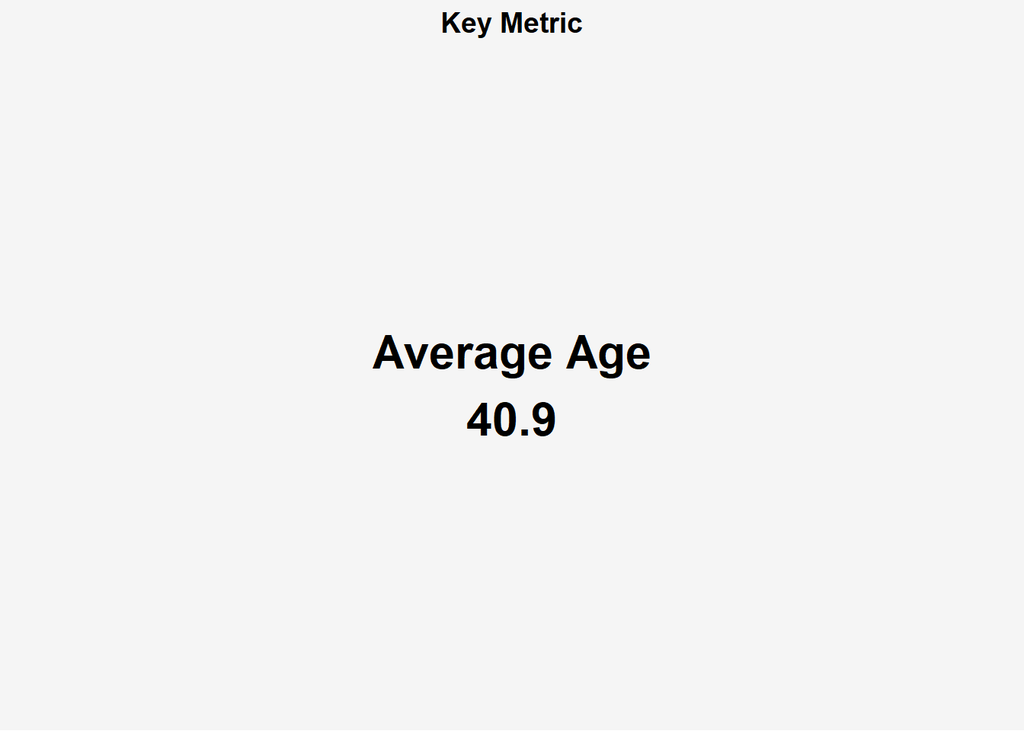

```r
#Create a data frame for ploting
age_data <- data.frame(Metric = "Average Age", Value = average_age)

#Plot

ggplot(data.frame(Age = average_age), aes(x = 1, y = Age)) + geom_text(aes(label = paste0("Average Age\n", round(Age, 1))), size = 8, fontface = "bold") + theme_void() + theme( plot.background = element_rect(fill = "#f5f5f5", color = NA), panel.background = element_rect(fill = "#f5f5f5", color = NA), plot.title = element_text(hjust = 0.5, face = "bold", size = 14) ) + labs(title = "Key Metric")
```

### **2. What is the gender distribution among respondents?**

```r
gender_distribution <- data2 %>%
  count(Gender, name = "Count")
  print(gender_distribution)
```

```
## # A tibble: 3 × 2
##   Gender Count
##   <chr>  <int>
## 1 Female    43
## 2 Male      49
## 3 Other      8
```

```r
table(data2$Gender)
```

```
##
## Female   Male  Other
##     43     49      8
```

*Plot - Gender Distribution*

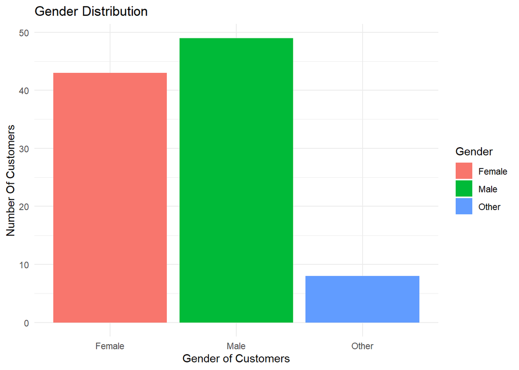

```r
# Gender Distribution among respondents
ggplot(gender_distribution, aes(x = Gender, y = Count, fill = Gender)) +
  geom_col() +
  labs(
      title = "Gender Distribution",
      x = "Gender of Customers",
      y = "Number Of Customers") +
      theme_minimal()
```

### **3. What are the most and least popular products?**

```r
# Most & Least Popular Products
product_counts <-
table(data2$Favorite_Product)
most_popular <-
names(product_counts[which.max(product_counts)])
least_popular <-
names(product_counts[which.min(product_counts)])
```

*Most Popular*

```r
print(paste("Most Popular Product:", most_popular))
```

```
## [1] "Most Popular Product: Tea"
```

*Least Popular*

```r
print(paste("Least Popular Product:", least_popular))
```

```
## [1] "Least Popular Product: Coffee"
```

**Plot** - **Most & Least Popular Products**

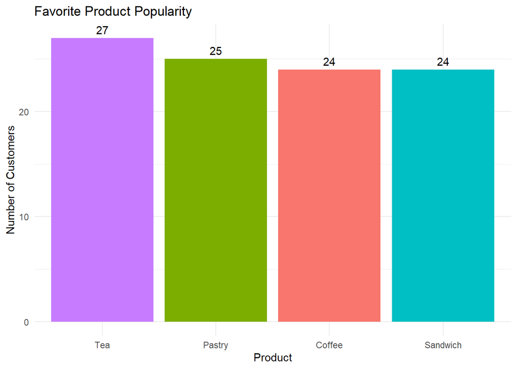

```r
# Create a data frame from the table
product_counts <- as.data.frame(table(data$Favorite_Product))
colnames(product_counts) <- c("Product", "Count")
# Plot
ggplot(product_counts, aes(x = reorder(Product, -Count), y = Count, fill = Product)) +
  geom_bar(stat = "identity") +
  labs(title = "Favorite Product Popularity",
       x = "Product", y = "Number of Customers") +
  theme_minimal() +
  theme(legend.position = "none") +
  geom_text(aes(label = Count), vjust = -0.5)
```

# **Relationship & Comparison Questions**

### **1. Does visit frequency differ by gender or age group?**

*By Gender*

```r
#By Gender
aggregate(Visit_Frequency ~ Gender, data2, FUN=mean)
```

```
##   Gender Visit_Frequency
## 1 Female        3.162791
## 2   Male        3.714286
## 3  Other        4.125000
```

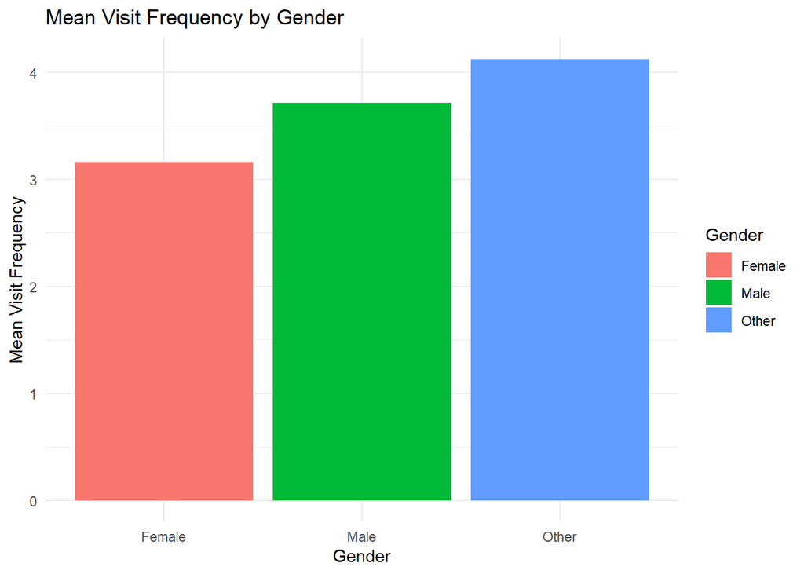

```r
data2_summary <- data2 %>%
  group_by(Gender) %>%
  summarize(Mean_Visit_Frequency = mean(Visit_Frequency, na.rm = TRUE))

ggplot(data2_summary, aes(x = Gender, y = Mean_Visit_Frequency, fill = Gender)) +
  geom_col() +
  labs(
    title = "Mean Visit Frequency by Gender",
    x = "Gender",
    y = "Mean Visit Frequency"
  ) +
  theme_minimal()
```

*By Age*

```r
#By Age
data2$Age_Group <- cut(data2$Age, breaks=c(0, 17, 29, 44, 59, 100), labels=c("Child", "Young Adult", "Adult", "Old", "Senior"))
aggregate(Visit_Frequency ~ Age_Group, data2, FUN=mean)
```

```
##     Age_Group Visit_Frequency
## 1 Young Adult        3.560000
## 2       Adult        3.675676
## 3         Old        3.333333
## 4      Senior        3.285714
```

[figure not shown]

```r
ggplot(data2, aes(x = Age_Group, y = Visit_Frequency, fill = Age_Group)) +
  geom_bar(stat = "identity") +
  labs(
    title = "Mean Visit Frequency by Age Group",
    x = "Age Group",
    y = "Mean Visit Frequency"
  ) +
  theme_minimal()
```

### **2. Is there a relationship between visit frequency and satisfaction score?**

*Correlation*

```r
cor(data2$Visit_Frequency, data2$Satisfaction_Score)
```

```
## [1] 0.0022235
```

*Plot - Correlation*

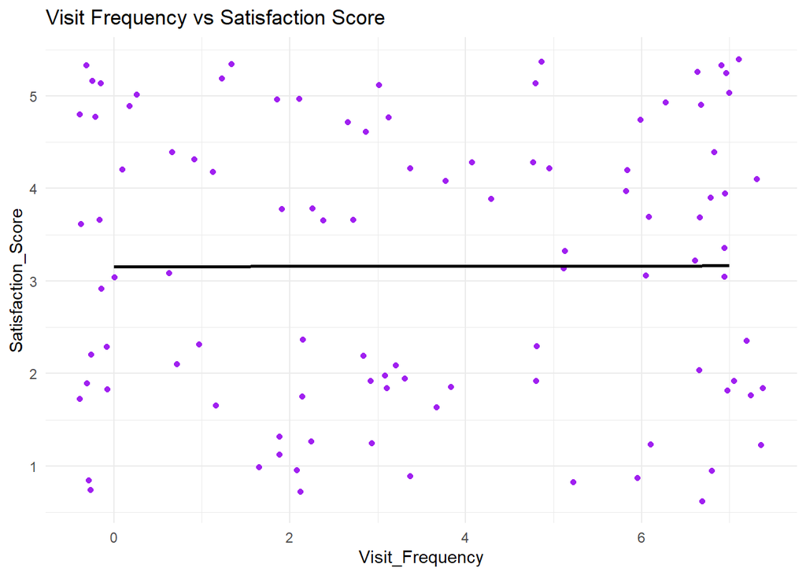

```r
ggplot(data, aes(x = Visit_Frequency, y = Satisfaction_Score)) + geom_jitter(color = "purple") + geom_smooth(method = "lm", se = FALSE, color = "black") + labs(title = "Visit Frequency vs Satisfaction Score") + theme_minimal()
```

### **3. Do loyalty members spend more time at the coffee shop than non-members?**

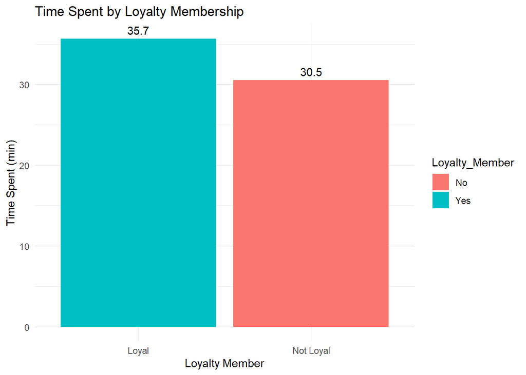

```r
# First, summarize the data

summary_data <- data2%>% group_by(Loyalty_Member) %>% summarise(Avg_Time_Spent = mean(Time_Spent_min, na.rm = TRUE))

# Then plot

ggplot(summary_data, aes(x = factor(Loyalty_Member, levels = c("Yes", "No"), labels = c("Loyal", "Not Loyal")), y = Avg_Time_Spent, fill = Loyalty_Member)) + geom_col() + geom_text(aes(label = round(Avg_Time_Spent, 1)), vjust = -0.5, color = "black") + labs(title = "Time Spent by Loyalty Membership", y = "Time Spent (min)", x = "Loyalty Member") + theme_minimal()
```

```r
t.test(Time_Spent_min ~ Loyalty_Member, data = data2)
```

```
##
##  Welch Two Sample t-test
##
## data:  Time_Spent_min by Loyalty_Member
## t = -1.7744, df = 95.64, p-value = 0.07917
## alternative hypothesis: true difference in means between group No and group Yes is not equal to 0
## 95 percent confidence interval:
##  -10.8888843   0.6100964
## sample estimates:
##  mean in group No mean in group Yes
##          30.53333          35.67273
```

The t-test indicates that loyalty program members tend to spend a bit more time in the coffee shop compared to non-members (average: 35.67 minutes vs. 30.53 minutes). However, the p-value (0.07917) exceeds the typical 0.05 significance level, implying that although there appears to be a slight difference, the evidence isn’t strong enough to confidently conclude that the pattern is real.

```r
chi_square_data <- table(data2$Would_Recommend, data2$Loyalty_Member)
print(chi_square_data)
```

```
##
##       No Yes
##   No   7  20
##   Yes 38  35
```

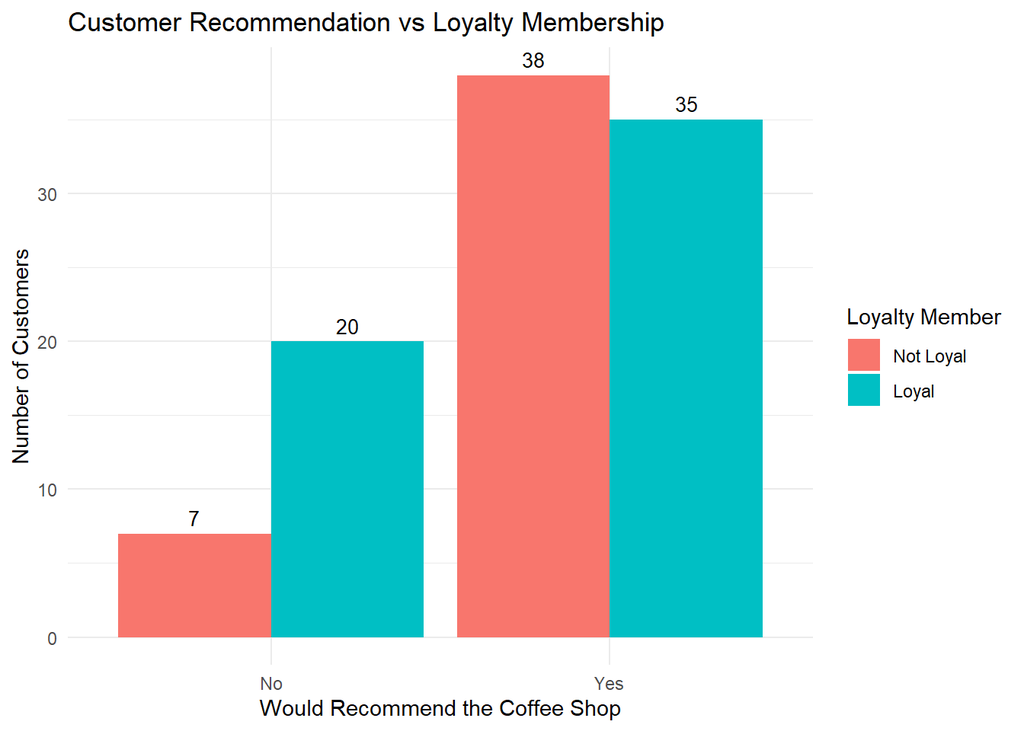

```r
chi_square_df <- as.data.frame(chi_square_data)
colnames(chi_square_df) <- c("Would_Recommend", "Loyalty_Member", "Count")

chi_square_df$Loyalty_Member <- factor(chi_square_df$Loyalty_Member,
                                       levels = c("No", "Yes"),
                                       labels = c("Not Loyal", "Loyal"))

ggplot(chi_square_df, aes(x = Would_Recommend, y = Count, fill = Loyalty_Member)) +
  geom_col(position = "dodge") +  # "dodge" makes bars side-by-side instead of stacked
  geom_text(aes(label = Count),
            position = position_dodge(width = 0.9),
            vjust = -0.5,
            size = 3.5) +  # Add labels on top of bars
  labs(title = "Customer Recommendation vs Loyalty Membership",
       x = "Would Recommend the Coffee Shop",
       y = "Number of Customers",
       fill = "Loyalty Member") +
  theme_minimal()
```

# **Insightful/Advanced Questions**

### **1. What factors (age, loyalty status, product_preference) are associated with higher satisfaction scores?**

```r
data_model <- data2 %>%
  select(Age, Loyalty_Member, Favorite_Product, Satisfaction_Score) %>%
  mutate(
    Loyalty_Member = factor(Loyalty_Member),
    Favorite_Product = factor(Favorite_Product)
  )

model <- lm(Satisfaction_Score ~ Age + Loyalty_Member + Favorite_Product, data = data_model)
summary(model)
```

```
##
## Call:
## lm(formula = Satisfaction_Score ~ Age + Loyalty_Member + Favorite_Product,
##     data = data_model)
##
## Residuals:
##     Min      1Q  Median      3Q     Max
## -2.4368 -1.2735  0.2607  1.4301  2.1268
##
## Coefficients:
##                            Estimate Std. Error t value Pr(>|t|)
## (Intercept)               2.8664388  0.5457193   5.253 9.31e-07 ***
## Age                       0.0003556  0.0106603   0.033    0.973
## Loyalty_MemberYes        -0.2866363  0.3007110  -0.953    0.343
## Favorite_ProductPastry    0.5423283  0.4247266   1.277    0.205
## Favorite_ProductSandwich  0.5539655  0.4256545   1.301    0.196
## Favorite_ProductTea       0.6227389  0.4164713   1.495    0.138
## ---
## Signif. codes:  0 '***' 0.001 '**' 0.01 '*' 0.05 '.' 0.1 ' ' 1
##
## Residual standard error: 1.473 on 94 degrees of freedom
## Multiple R-squared:  0.03501,    Adjusted R-squared:  -0.01632
## F-statistic: 0.682 on 5 and 94 DF,  p-value: 0.6382
```

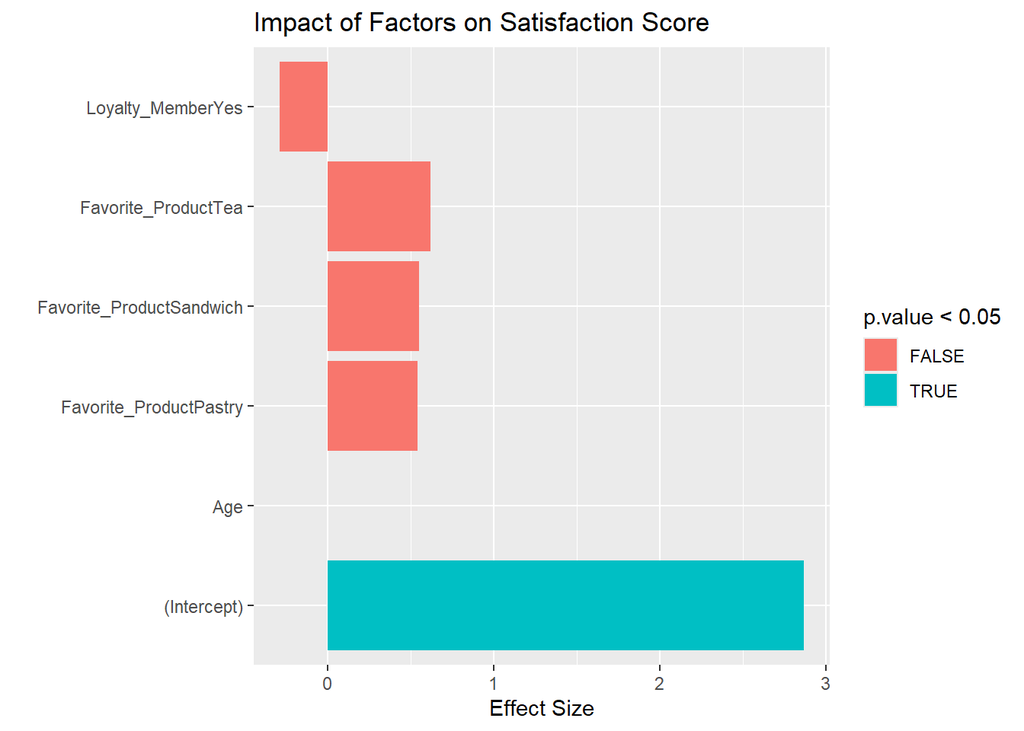

```r
library(broom)

tidy(model) %>%
  ggplot(aes(x = term, y = estimate, fill = p.value < 0.05)) +
  geom_col() +
  coord_flip() +
  labs(title = "Impact of Factors on Satisfaction Score",
       y = "Effect Size", x = "")
```

### **2. Is there a difference in satisfaction scores between customers who prefer coffee and those who prefer pastries?**

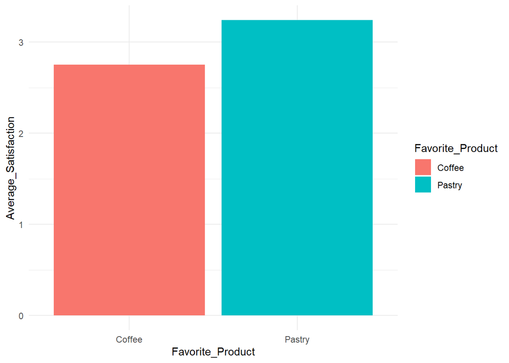

```r
coffee_pastries <- data2 %>%
  filter(Favorite_Product %in% c('Coffee', 'Pastry')) %>%
  group_by(Favorite_Product) %>%
  summarise(Average_Satisfaction = mean(Satisfaction_Score)) %>%
  ggplot(aes(x = Favorite_Product, y = Average_Satisfaction, fill = Favorite_Product)) +
  geom_col() +
  theme_minimal()

print(coffee_pastries)
```

### **3. Can we predict whether a customer would recommend the coffee shop based on other variables?**

```r
# Prepare data
data_model <- data2 %>%
  select(Would_Recommend, Gender, Satisfaction_Score, Age, Loyalty_Member, Visit_Frequency) %>%
  mutate(
    recommend = ifelse(Would_Recommend == "Yes", 1, 0),
    Loyalty_Member = as.factor(Loyalty_Member),
    Gender = as.factor(Gender)
  ) %>%
  drop_na()
```

```r
# Fit logistic regression
log_model <- glm(recommend ~ Satisfaction_Score + Age + Loyalty_Member + Visit_Frequency + Gender, data = data_model, family = "binomial")

summary(log_model)
```

```
##
## Call:
## glm(formula = recommend ~ Satisfaction_Score + Age + Loyalty_Member +
##     Visit_Frequency + Gender, family = "binomial", data = data_model)
##
## Coefficients:
##                    Estimate Std. Error z value Pr(>|z|)
## (Intercept)         0.27569    1.00178   0.275   0.7832
## Satisfaction_Score  0.35785    0.17714   2.020   0.0434 *
## Age                 0.02808    0.01793   1.566   0.1174
## Loyalty_MemberYes  -1.23163    0.55007  -2.239   0.0252 *
## Visit_Frequency    -0.10963    0.09904  -1.107   0.2684
## GenderMale         -0.56619    0.52141  -1.086   0.2775
## GenderOther         0.08009    1.22289   0.065   0.9478
## ---
## Signif. codes:  0 '***' 0.001 '**' 0.01 '*' 0.05 '.' 0.1 ' ' 1
##
## (Dispersion parameter for binomial family taken to be 1)
##
##     Null deviance: 116.65  on 99  degrees of freedom
## Residual deviance: 101.92  on 93  degrees of freedom
## AIC: 115.92
##
## Number of Fisher Scoring iterations: 5
```

Yes, **we can partially predict** whether a customer would recommend the coffee shop:

- **Satisfaction Score** is the strongest positive predictor (p = 0.043)
- **Loyalty status** unexpectedly shows a negative effect (p = 0.025)

Other factors (age, gender, visit frequency) do not show significant effects in this model.